# user collab with PCA and maybe recommenderlab

```r
#plot(cars)
```

### Read in the data

We start by loading some libraries and reading in the two data files.

```r
library(recommenderlab)
library(data.table)
library(dplyr)
library(tidyr)
library(ggplot2)
library(stringr)
library(DT)
library(knitr)
library(grid)
library(gridExtra)
library(corrplot)
library(qgraph)
library(methods)
library(Matrix)
books <- fread('../books.csv')
ratings <- fread('../ratings.csv')
#book_tags <- fread('../book_tags.csv')
#tags <- fread('../tags.csv')
```

So let’s first remove the duplicate ratings.

```r
ratings[, N := .N, .(user_id, book_id)]
## corresponding dplyr code
# ratings %>% group_by(user_id, book_id) %>% mutate(n=n())
cat('Number of duplicate ratings: ', nrow(ratings[N > 1]))
```

```
Number of duplicate ratings:  0
```

```r
ratings <- ratings[N == 1]
```

And then let’s remove users who rated fewer than 5 books.

```r
ratings[, N := .N, .(user_id)]
ratings[, B := .N, .(book_id)]
## corresponding dplyr code
# ratings %>% group_by(user_id) %>% mutate(n = n())
cat('Number of users who rated fewer than 5 books: ', uniqueN(ratings[N <= 5, user_id]))
```

```
Number of users who rated fewer than 5 books:  0
```

```r
ratings <- ratings[N > 5]
cat('Number of book who rated fewer than 5 books: ', uniqueN(ratings[B <= 5, book_id]))
```

```
Number of book who rated fewer than 5 books:  0
```

```r
ratings <- ratings[B > 5]
cat('Number of users who rated fewer than 5 books g: ', uniqueN(ratings[N <= 5, user_id]))
```

```
Number of users who rated fewer than 5 books g:  0
```

```r
ratings <- ratings[N > 5]
cat('Number of book who rated fewer than 5 books g: ', uniqueN(ratings[B <= 5, book_id]))
```

```
Number of book who rated fewer than 5 books g:  0
```

```r
ratings <- ratings[B > 5]
glimpse(ratings)
```

```
Observations: 5,976,479
Variables: 5
$ user_id <int> 1, 2, 2, 2, 2, 2, 2, 2, 2, 2, 2, 2, 4, 4, 4, 4, 4, 4, 4, 4, 4, 4, 4, 4...
$ book_id <int> 258, 4081, 260, 9296, 2318, 26, 315, 33, 301, 2686, 3753, 8519, 70, 26...
$ rating  <int> 5, 4, 5, 5, 3, 4, 3, 4, 5, 5, 5, 5, 4, 3, 4, 5, 5, 5, 5, 5, 5, 4, 5, 2...
$ N       <int> 117, 65, 65, 65, 65, 65, 65, 65, 65, 65, 65, 65, 134, 134, 134, 134, 1...
$ B       <int> 3531, 388, 1767, 112, 389, 13072, 1826, 11304, 4377, 172, 233, 123, 88...
```

```r
length(unique(ratings$book_id))
```

```
[1] 10000
```

```r
length(unique(ratings$user_id))
```

```
[1] 53424
```

Setup to remove users have nearly nothing in common with target user.

```r
ratings[, Bmean := mean(rating), .(book_id)]
ratings[, MisMean := signif(rating-Bmean,digits = 3),]
ratings[, shadow := 1,] # then use shadow numbers instead of rating for matix
glimpse(ratings)
```

```
Observations: 5,976,479
Variables: 8
$ user_id <int> 1, 2, 2, 2, 2, 2, 2, 2, 2, 2, 2, 2, 4, 4, 4, 4, 4, 4, 4, 4, 4, 4, 4, 4...
$ book_id <int> 258, 4081, 260, 9296, 2318, 26, 315, 33, 301, 2686, 3753, 8519, 70, 26...
$ rating  <int> 5, 4, 5, 5, 3, 4, 3, 4, 5, 5, 5, 5, 4, 3, 4, 5, 5, 5, 5, 5, 5, 4, 5, 2...
$ N       <int> 117, 65, 65, 65, 65, 65, 65, 65, 65, 65, 65, 65, 134, 134, 134, 134, 1...
$ B       <int> 3531, 388, 1767, 112, 389, 13072, 1826, 11304, 4377, 172, 233, 123, 88...
$ Bmean   <dbl> 4.105919, 3.293814, 3.894737, 3.946429, 3.871465, 3.620946, 3.399781, ...
$ MisMean <dbl> 0.89400, 0.70600, 1.11000, 1.05000, -0.87100, 0.37900, -0.40000, -0.00...
$ shadow  <dbl> 1, 1, 1, 1, 1, 1, 1, 1, 1, 1, 1, 1, 1, 1, 1, 1, 1, 1, 1, 1, 1, 1, 1, 1...
```

```r
ot.use.touch <- ratings[,
        .(sum(B)),
        by = .(user_id)]
bk.ct.b.use <- ratings[,
        .(.N),
        by = .(user_id)]
glimpse(ot.use.touch)
```

```
Observations: 53,424
Variables: 2
$ user_id <int> 1, 2, 4, 6, 8, 9, 11, 15, 18, 22, 24, 25, 28, 32, 29, 34, 40, 31, 43, ...
$ V1      <int> 560786, 322084, 765097, 160909, 320638, 684285, 435453, 489464, 347240...
```

```r
glimpse(bk.ct.b.use)
```

```
Observations: 53,424
Variables: 2
$ user_id <int> 1, 2, 4, 6, 8, 9, 11, 15, 18, 22, 24, 25, 28, 32, 29, 34, 40, 31, 43, ...
$ N       <int> 117, 65, 134, 90, 98, 132, 120, 97, 109, 120, 128, 60, 120, 123, 98, 1...
```

```r
summary(ot.use.touch)
```

```
    user_id            V1
 Min.   :    1   Min.   :   4705
 1st Qu.:13357   1st Qu.: 235673
 Median :26713   Median : 355281
 Mean   :26713   Mean   : 367446
 3rd Qu.:40068   3rd Qu.: 482716
 Max.   :53424   Max.   :1197398
```

```r
#ratings[, M := .(mean()), .(book_id)]
#book.mean <- ratings[,
 #       .(mean()),
#        by = .(book_id)]
```

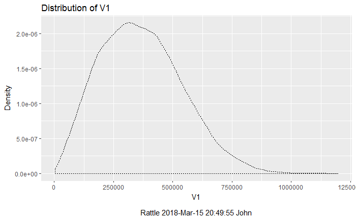

```r
# Generate the plot.
p01 <- ot.use.touch %>%
  #dplyr::select(V1) %>%
  ggplot2::ggplot(ggplot2::aes(x=V1)) +
  ggplot2::geom_density(lty=3) +
  ggplot2::xlab("V1\n\nRattle 2018-Mar-15 20:49:55 John") +
  ggplot2::ggtitle("Distribution of V1") +
  ggplot2::labs(y="Density")
# Display the plots.
gridExtra::grid.arrange(p01)
```

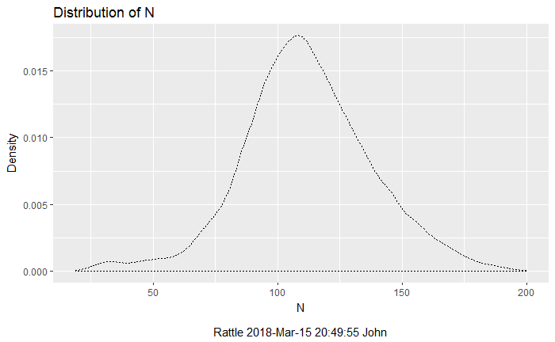

```r
# Generate the plot.
p01 <- bk.ct.b.use %>%
  #dplyr::select(V1) %>%
  ggplot2::ggplot(ggplot2::aes(x=N)) +
  ggplot2::geom_density(lty=3) +
  ggplot2::xlab("N\n\nRattle 2018-Mar-15 20:49:55 John") +
  ggplot2::ggtitle("Distribution of N") +
  ggplot2::labs(y="Density")
# Display the plots.
gridExtra::grid.arrange(p01)
```

pick the target user

```r
set.seed(1)
users <- unique(ratings$user_id)
max(users==17329)
```

```
[1] 1
```

```r
ot.use.touch[ot.use.touch$user_id==17329]
```

| user_id | V1 |
| --- | --- |
| 17329 | 617489 |

```r
identical(ot.use.touch$user_id,users)
```

```
[1] TRUE
```

```r
summary(sele.usr<-ot.use.touch$V1>750000)
```

```
   Mode   FALSE    TRUE
logical   52273    1151
```

```r
head(sele.usr)
```

```
[1] FALSE FALSE  TRUE FALSE FALSE FALSE
```

```r
ot.use.touch[3]
```

| user_id | V1 |
| --- | --- |
| 4 | 765097 |

```r
bk.ct.b.use[3]
```

| user_id | N |
| --- | --- |
| 4 | 134 |

Now that we have selected a user lets remove all books not rated by user.

```r
userated<-ratings[user_id==4]
glimpse(userated)
```

```
Observations: 134
Variables: 8
$ user_id <int> 4, 4, 4, 4, 4, 4, 4, 4, 4, 4, 4, 4, 4, 4, 4, 4, 4, 4, 4, 4, 4, 4, 4, 4...
$ book_id <int> 70, 264, 388, 18, 27, 21, 2, 23, 24, 964, 103, 255, 35, 287, 337, 26, ...
$ rating  <int> 4, 3, 4, 5, 5, 5, 5, 5, 5, 4, 5, 2, 5, 3, 4, 3, 4, 4, 3, 3, 2, 4, 4, 4...
$ N       <int> 134, 134, 134, 134, 134, 134, 134, 134, 134, 134, 134, 134, 134, 134, ...
$ B       <int> 8849, 4161, 2392, 15855, 15081, 15258, 21850, 15657, 15523, 1400, 5489...
$ Bmean   <dbl> 4.258221, 3.725787, 3.600334, 4.418732, 4.443339, 4.358697, 4.351350, ...
$ MisMean <dbl> -0.25800, -0.72600, 0.40000, 0.58100, 0.55700, 0.64100, 0.64900, 0.771...
$ shadow  <dbl> 1, 1, 1, 1, 1, 1, 1, 1, 1, 1, 1, 1, 1, 1, 1, 1, 1, 1, 1, 1, 1, 1, 1, 1...
```

```r
thisway<-(ratings$book_id %in% userated$book_id)
summary(thisway)
```

```
   Mode   FALSE    TRUE
logical 5211382  765097
```

```r
useable.rats<-ratings[thisway]
glimpse(useable.rats)
```

```
Observations: 765,097
Variables: 8
$ user_id <int> 2, 2, 2, 4, 4, 4, 4, 4, 4, 4, 4, 4, 4, 4, 4, 4, 4, 4, 4, 4, 4, 4, 4, 4...
$ book_id <int> 26, 33, 301, 70, 264, 388, 18, 27, 21, 2, 23, 24, 964, 103, 255, 35, 2...
$ rating  <int> 4, 4, 5, 4, 3, 4, 5, 5, 5, 5, 5, 5, 4, 5, 2, 5, 3, 4, 3, 4, 4, 3, 3, 2...
$ N       <int> 65, 65, 65, 134, 134, 134, 134, 134, 134, 134, 134, 134, 134, 134, 134...
$ B       <int> 13072, 11304, 4377, 8849, 4161, 2392, 15855, 15081, 15258, 21850, 1565...
$ Bmean   <dbl> 3.620946, 4.001327, 3.390222, 4.258221, 3.725787, 3.600334, 4.418732, ...
$ MisMean <dbl> 0.37900, -0.00133, 1.61000, -0.25800, -0.72600, 0.40000, 0.58100, 0.55...
$ shadow  <dbl> 1, 1, 1, 1, 1, 1, 1, 1, 1, 1, 1, 1, 1, 1, 1, 1, 1, 1, 1, 1, 1, 1, 1, 1...
```

And then let’s pick number for number of users to remove.

```r
useable.rats[, N := .N, .(user_id)]
useable.rats[, B := .N, .(book_id)]
summary(useable.rats$N)
```

```
   Min. 1st Qu.  Median    Mean 3rd Qu.    Max.
   1.00   14.00   20.00   21.27   28.00  134.00
```

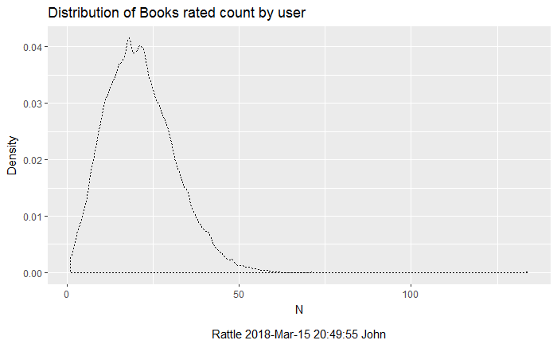

```r
# Generate the plot.
#with(useable.rats, qqPlot(N, dist="norm", id.method="y", id.n=2,
#  labels=rownames(useable.rats)))
p01 <- useable.rats %>%
  #dplyr::select(V1) %>%
  ggplot2::ggplot(ggplot2::aes(x=N)) +
  ggplot2::geom_density(lty=3) +
  ggplot2::xlab("N\n\nRattle 2018-Mar-15 20:49:55 John") +
  ggplot2::ggtitle("Distribution of Books rated count by user") +
  ggplot2::labs(y="Density")
# Display the plots.
gridExtra::grid.arrange(p01)
```

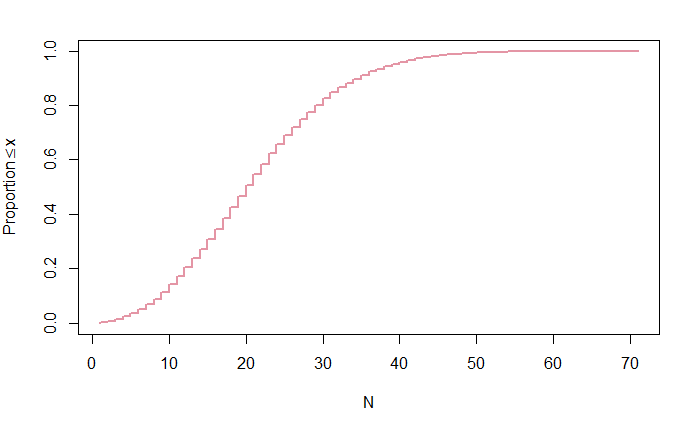

```r
# Generate just the data for an Ecdf plot of the variable 'N'.
ds <- rbind(data.frame(dat=useable.rats[user_id!=4,N], grp="All"))
# The 'Hmisc' package provides the 'Ecdf' function.
library(Hmisc, quietly=TRUE)
# Plot the data.
Ecdf(ds[ds$grp=="All",1], col="#E495A5", xlab="N", lwd=2, ylab=expression(Proportion <= x), subtitles=FALSE)
```

Pick the specific number.

```r
## corresponding dplyr code
# useable.rats %>% group_by(user_id) %>% mutate(n = n())
cat('Number of users who rated fewer than 20 books: ', uniqueN(useable.rats[N <= 20, user_id]))
```

```
Number of users who rated fewer than 20 books:  37399
```

```r
useable.rats <- useable.rats[N > 20]
```

```r
#dimension_names <- list(user_id = sort(unique(useable.rats$user_id)), book_id = sort(unique(useable.rats$book_id)))
#ratingmat <- spread(select(useable.rats, book_id, user_id, rating), book_id, rating) %>% select(-user_id)
#ratingmat <- as.matrix(ratingmat)
#dimnames(ratingmat) <- dimension_names
#ratingmat[1:5, 1:5]
#dim(ratingmat)
```

```r
useable.rats[, N := .N, .(user_id)]
useable.rats[, B := .N, .(book_id)]
useable.rats[, rankuser := frank(user_id,ties.method="dense"),]
useable.rats[, rankbook := frank(book_id,ties.method="dense"),]
cat('Number of book who rated fewer than 5 books g: ', uniqueN(useable.rats[B <= 5, book_id]))
```

```
Number of book who rated fewer than 5 books g:  0
```

```r
useable.rats <- useable.rats[B > 5]
glimpse(useable.rats)
```

```
Observations: 378,877
Variables: 10
$ user_id  <int> 4, 4, 4, 4, 4, 4, 4, 4, 4, 4, 4, 4, 4, 4, 4, 4, 4, 4, 4, 4, 4, 4, 4, 4, 4, 4, 4, ...
$ book_id  <int> 70, 264, 388, 18, 27, 21, 2, 23, 24, 964, 103, 255, 35, 287, 337, 26, 84, 58, 111...
$ rating   <int> 4, 3, 4, 5, 5, 5, 5, 5, 5, 4, 5, 2, 5, 3, 4, 3, 4, 4, 3, 3, 2, 4, 4, 4, 4, 4, 4, ...
$ N        <int> 134, 134, 134, 134, 134, 134, 134, 134, 134, 134, 134, 134, 134, 134, 134, 134, 1...
$ B        <int> 3860, 2422, 1021, 7137, 6697, 6718, 9082, 6942, 6949, 686, 3039, 2443, 3928, 2242...
$ Bmean    <dbl> 4.258221, 3.725787, 3.600334, 4.418732, 4.443339, 4.358697, 4.351350, 4.229418, 4...
$ MisMean  <dbl> -0.25800, -0.72600, 0.40000, 0.58100, 0.55700, 0.64100, 0.64900, 0.77100, 0.56900...
$ shadow   <dbl> 1, 1, 1, 1, 1, 1, 1, 1, 1, 1, 1, 1, 1, 1, 1, 1, 1, 1, 1, 1, 1, 1, 1, 1, 1, 1, 1, ...
$ rankuser <int> 2, 2, 2, 2, 2, 2, 2, 2, 2, 2, 2, 2, 2, 2, 2, 2, 2, 2, 2, 2, 2, 2, 2, 2, 2, 2, 2, ...
$ rankbook <int> 33, 70, 88, 10, 18, 12, 1, 14, 15, 114, 47, 69, 22, 72, 80, 17, 36, 30, 117, 105,...
```

```r
ot.use.touch2 <- useable.rats[,
        .(sum(B)),
        by = .(user_id)]
bk.ct.b.use2 <- useable.rats[,
        .(.N),
        by = .(user_id)]

#useable.rats <- useable.rats[user_id != 4]
#summary(bk.ct.b.use2)
#summary(ot.use.touch2)
length(unique(useable.rats$user_id))
```

```
[1] 13599
```

```r
length(unique(useable.rats$book_id))
```

```
[1] 134
```

```r
length((useable.rats$book_id))
```

```
[1] 378877
```

```r
summary(useable.rats$B)
```

```
   Min. 1st Qu.  Median    Mean 3rd Qu.    Max.
     43    2441    4594    4650    6728    9100
```

```r
useable.rats[1]
```

| user_id | book_id | rating | N | B | Bmean | MisMean | shadow | rankuser | rankbook |
| --- | --- | --- | --- | --- | --- | --- | --- | --- | --- |
| 4 | 70 | 4 | 134 | 3860 | 4.258221 | -0.258 | 1 | 2 | 33 |

```r
max(useable.rats$book_id)
```

```
[1] 8464
```

```r
max(useable.rats$user_id)
```

```
[1] 53422
```

```r
max(useable.rats$rankbook)
```

```
[1] 134
```

Second attempt.

```r
library(Matrix);library(irlba)
set.seed(42)
#rows <- 500000
#cols <- 10000
#i <- unlist(lapply(1:rows, function(i) rep(i, sample(1:5,1))))
#j <- sample(1:cols, length(i), replace=TRUE)
#M <- sparseMatrix(i, j)
#SM<-sparseMatrix(ratings$user_id,ratings$book_id,x=ratings$rating)
SM<-sparseMatrix(useable.rats$rankuser,useable.rats$rankbook,
                x=useable.rats$MisMean)
str(SM)
```

```
Formal class 'dgCMatrix' [package "Matrix"] with 6 slots
  ..@ i       : int [1:378877] 1 3 6 7 8 9 11 12 15 16 ...
  ..@ p       : int [1:135] 0 9082 18182 26612 34013 41989 48434 54346 62144 69927 ...
  ..@ Dim     : int [1:2] 13599 134
  ..@ Dimnames:List of 2
  .. ..$ : NULL
  .. ..$ : NULL
  ..@ x       : num [1:378877] 0.649 -0.351 0.649 -0.351 -1.35 -1.35 -0.351 -0.351 0.649 -0.351 ...
  ..@ factors : list()
```

```r
str(SM[-2,])
```

```
Formal class 'dgCMatrix' [package "Matrix"] with 6 slots
  ..@ i       : int [1:378743] 2 5 6 7 8 10 11 14 15 16 ...
  ..@ p       : int [1:135] 0 9081 18180 26609 34009 41984 48428 54339 62136 69918 ...
  ..@ Dim     : int [1:2] 13598 134
  ..@ Dimnames:List of 2
  .. ..$ : NULL
  .. ..$ : NULL
  ..@ x       : num [1:378743] -0.351 0.649 -0.351 -1.35 -1.35 -0.351 -0.351 0.649 -0.351 -1.35 ...
  ..@ factors : list()
```

```r
#summary(SM)
length(unique(SM@i));max(SM@i)
```

```
[1] 13599
[1] 13598
```

```r
SM@p
```

```
  [1]      0   9082  18182  26612  34013  41989  48434  54346  62144  69927  77064  83119  89837  94925
 [15] 101867 108816 115544 121799 128496 136198 143170 148565 152493 157087 162561 167583 173084 177590
 [29] 182377 187943 193634 197252 202108 205968 209004 211243 214512 218215 220859 224219 228041 231121
 [43] 234291 237296 240683 243596 246904 249943 252319 256436 260558 263618 266213 267891 271546 276057
 [57] 277721 280865 283503 285944 288315 289959 292816 293926 295340 297348 298968 300897 302462 304905
 [71] 307327 309608 311850 313161 315159 317641 319764 322011 323659 325837 327671 329197 330727 332960
 [85] 334361 335343 336510 338517 339538 340740 342598 344018 345718 346975 348634 350589 351511 352582
 [99] 353991 355148 356127 357341 358474 359454 360385 361592 362282 363393 364731 365410 366801 367874
[113] 368965 369723 370409 370979 371573 372280 372866 373227 373696 374188 374736 375144 375605 375969
[127] 376640 377031 377376 377763 378245 378496 378659 378834 378877
```

```r
SM
```

```
13599 x 134 sparse Matrix of class "dgCMatrix"

 [1,]  .      0.671  .      .      .    -0.187  0.831 -0.0468  .      .      .      .     -0.631  .      .
 [2,]  0.649 -0.329  0.228 -0.148  0.29  0.813 -0.169 -0.0468 -0.826  0.581 -2.270  0.641 -2.630  0.771  0.569
 [3,]  .     -1.330 -0.772  .      .    -3.190  .     -0.0468  1.170  .      .      .      .      .      .
 [4,] -0.351  .      1.230  .      .     0.813 -3.170  0.9530  0.174  0.581  .     -1.360 -0.631 -1.230 -1.430
 [5,]  .      0.671  1.230  .      .     0.813 -1.170  .       .      .      0.728  .      .      .      .
 [6,]  .     -1.330  .      .      1.29  .     -0.169  .       .      .      .      .      .      .      .
 [7,]  0.649 -0.329 -1.770  .      0.29  .      0.831  .       1.170  .      0.728  .     -0.631  .      .
 [8,] -0.351 -1.330  0.228  .      1.29  0.813  0.831 -0.0468  0.174 -0.419  .     -1.360  .      .     -0.431
 [9,] -1.350 -0.329 -0.772 -1.150 -0.71 -0.187  .      .      -0.826 -1.420 -0.272  .      .     -1.230  .
[10,] -1.350 -0.329  0.228  .      0.29 -0.187 -0.169  .       .     -1.420  .     -1.360  .     -1.230 -0.431
[11,]  .      0.671 -0.772  .      0.29  .      0.831  .       .      .      .      .      1.370  .      .
[12,] -0.351  .     -0.772  .      0.29  .      0.831  0.9530  1.170 -0.419 -0.272 -0.359  .     -0.229 -0.431

```

[output cut: 42 more lines]

```r
rm(books, ratings,useable.rats,bk.ct.b.use,bk.ct.b.use2,
   ot.use.touch,ot.use.touch2)
gc()
```

```r
useable.rats$book_id
```

[output not shown]

[output cut: 39 more lines]

```r
 set.seed(1)
 p1 <- prcomp_irlba(SM[-2,], n=60)
 summary(p1)
```

```
Importance of components:
                           PC1     PC2    PC3     PC4     PC5     PC6     PC7     PC8     PC9    PC10
Standard deviation     1.47897 1.20296 0.8713 0.82652 0.77467 0.74938 0.72376 0.70261 0.68327 0.66320
Proportion of Variance 0.08327 0.05509 0.0289 0.02601 0.02285 0.02138 0.01994 0.01879 0.01777 0.01674
Cumulative Proportion  0.08327 0.13836 0.1673 0.19327 0.21612 0.23750 0.25744 0.27623 0.29401 0.31075
                          PC11    PC12    PC13    PC14    PC15    PC16    PC17    PC18    PC19    PC20
Standard deviation     0.65464 0.64069 0.63337 0.62184 0.61827 0.60888 0.60185 0.59471 0.58254 0.58041
Proportion of Variance 0.01632 0.01563 0.01527 0.01472 0.01455 0.01411 0.01379 0.01346 0.01292 0.01283
Cumulative Proportion  0.32707 0.34269 0.35797 0.37269 0.38724 0.40135 0.41514 0.42861 0.44153 0.45435
                          PC21    PC22    PC23   PC24    PC25    PC26    PC27    PC28    PC29    PC30
Standard deviation     0.57404 0.56914 0.56527 0.5614 0.54618 0.53811 0.53327 0.52910 0.52626 0.52344
Proportion of Variance 0.01254 0.01233 0.01216 0.0120 0.01136 0.01102 0.01083 0.01066 0.01054 0.01043
Cumulative Proportion  0.46690 0.47923 0.49139 0.5034 0.51475 0.52577 0.53660 0.54726 0.55780 0.56823
                          PC31   PC32   PC33    PC34    PC35    PC36    PC37    PC38    PC39    PC40
Standard deviation     0.51623 0.5125 0.5075 0.50620 0.50080 0.48440 0.47953 0.46616 0.46269 0.45809
Proportion of Variance 0.01015 0.0100 0.0098 0.00976 0.00955 0.00893 0.00875 0.00827 0.00815 0.00799
Cumulative Proportion  0.57838 0.5884 0.5982 0.60794 0.61748 0.62642 0.63517 0.64344 0.65159 0.65958
                         PC41    PC42    PC43    PC44    PC45    PC46    PC47    PC48    PC49    PC50
Standard deviation     0.4527 0.44859 0.44259 0.43927 0.43414 0.42735 0.42590 0.42405 0.42073 0.42017
Proportion of Variance 0.0078 0.00766 0.00746 0.00735 0.00718 0.00695 0.00691 0.00685 0.00674 0.00672
Cumulative Proportion  0.6674 0.67505 0.68250 0.68985 0.69702 0.70398 0.71088 0.71773 0.72447 0.73119
                          PC51    PC52    PC53    PC54    PC55    PC56    PC57   PC58    PC59    PC60
Standard deviation     0.41676 0.41611 0.40930 0.40395 0.40263 0.40175 0.39826 0.3938 0.38619 0.38518
Proportion of Variance 0.00661 0.00659 0.00638 0.00621 0.00617 0.00614 0.00604 0.0059 0.00568 0.00565
Cumulative Proportion  0.73780 0.74439 0.75077 0.75698 0.76315 0.76930 0.77534 0.7812 0.78692 0.79257
```

```r
 str(p1)#ratings[user_id==4,,]
```

```
List of 6
 $ scale   : logi FALSE
 $ totalvar: num 26.3
 $ sdev    : num [1:60] 1.479 1.203 0.871 0.827 0.775 ...
 $ rotation: num [1:134, 1:60] -0.196 -0.185 -0.249 -0.186 -0.259 ...
  ..- attr(*, "dimnames")=List of 2
  .. ..$ : NULL
  .. ..$ : chr [1:60] "PC1" "PC2" "PC3" "PC4" ...
 $ center  : num [1:134] -0.037196 0.015299 0.000922 -0.015936 0.010424 ...
 $ x       : num [1:13598, 1:60] 0.355 0.632 0.571 -0.338 0.102 ...
  ..- attr(*, "dimnames")=List of 2
  .. ..$ : NULL
  .. ..$ : chr [1:60] "PC1" "PC2" "PC3" "PC4" ...
 - attr(*, "class")= chr [1:2] "irlba_prcomp" "prcomp"
```

```r
 #data.table(SM[2,],p1$rotation)
 write.table( data.table(SM[2,],p1$rotation),file = "4thbookrcentPCA.csv",quote = F,sep = ",",row.names = F ,col.names = F)
```

Using recommenderlab

Recommenderlab is a R-package that provides the infrastructure to evaluate and compare several collaborative-filtering algortihms. Many algorithms are already implemented in the package, and we can use the available ones to save some coding effort, or add custom algorithms and use the infrastructure (e.g. crossvalidation).

To restructure our rating data from this dataset in the same way, we can do the following:

```r
dimension_names <- list(user_id = sort(unique(useable.rats$user_id)), book_id = sort(unique(useable.rats$book_id)))
ratingmat <- spread(select(useable.rats, book_id, user_id, rating), book_id, rating) %>% select(-user_id)
ratingmat <- as.matrix(ratingmat)
dimnames(ratingmat) <- dimension_names
ratingmat[1:5, 1:5]
```

```
       book_id
user_id  2  4  5  7  8
     1  NA  5 NA NA NA
     4   5  4  4  4  4
     8  NA  3  3 NA NA
     9   4 NA  5 NA NA
     10 NA  5  5 NA NA
```

```r
dim(ratingmat)
```

```
[1] 13599   134
```

```r
ratingmat0 <- ratingmat
ratingmat0[is.na(ratingmat0)] <- 0
sparse_ratings <- as(ratingmat0, "sparseMatrix")
rm(ratingmat0)
gc()
```

Recommenderlab uses as special variant of a sparse matrices, so we convert to this class first.

```r
str(real_ratings)
```

```
Formal class 'realRatingMatrix' [package "recommenderlab"] with 2 slots
  ..@ data     :Formal class 'dgCMatrix' [package "Matrix"] with 6 slots
  .. .. ..@ i       : int [1:378877] 1 3 6 7 8 9 11 12 15 16 ...
  .. .. ..@ p       : int [1:135] 0 9082 18182 26612 34013 41989 48434 54346 62144 69927 ...
  .. .. ..@ Dim     : int [1:2] 13599 134
  .. .. ..@ Dimnames:List of 2
  .. .. .. ..$ user_id: chr [1:13599] "1" "4" "8" "9" ...
  .. .. .. ..$ book_id: chr [1:134] "2" "4" "5" "7" ...
  .. .. ..@ x       : num [1:378877] 5 4 5 4 3 3 4 4 5 4 ...
  .. .. ..@ factors : list()
  ..@ normalize: NULL
```

```r
str(unreal_ratings)
```

```
Formal class 'realRatingMatrix' [package "recommenderlab"] with 2 slots
  ..@ data     :Formal class 'dgCMatrix' [package "Matrix"] with 6 slots
  .. .. ..@ i       : int [1:378877] 1 3 6 7 8 9 11 12 15 16 ...
  .. .. ..@ p       : int [1:135] 0 9082 18182 26612 34013 41989 48434 54346 62144 69927 ...
  .. .. ..@ Dim     : int [1:2] 13599 134
  .. .. ..@ Dimnames:List of 2
  .. .. .. ..$ : NULL
  .. .. .. ..$ : NULL
  .. .. ..@ x       : num [1:378877] 0.649 -0.351 0.649 -0.351 -1.35 -1.35 -0.351 -0.351 0.649 -0.351 ...
  .. .. ..@ factors : list()
  ..@ normalize: NULL
```

Running an algorithm in Recommenderlab is really easy. All you have to do is call `Recommender()` and pass the data, select a method (“UBCF” - user-based collaborative filtering) and pass some params (e.g., the *method* for calculating similarity, e.g. *pearson*, and the number of most similar users used for the predictions, *nn*, e.g. 4).

```r
model <- Recommender(real_ratings, method = "UBCF", param = list(method = "pearson", nn = 4))
```

Creating predictions is then also straight-forward. You just call `predict()` and pass the model, the ratings for the user you want to predict ratings for, and a parameter to tell the function that you want to get predicted ratings back.

```r
#Making predictions
prediction <- predict(model, real_ratings[current_user, ], type = "ratings")
```

```r
as(prediction, 'data.frame') %>%
  arrange(-rating) %>% .[1:5,] %>%
  mutate(book_id = as.numeric(as.character(item))) %>%
  left_join(select(books, authors, title, book_id), by = "book_id") %>%
  select(-item) %>%
  datatable(class = "nowrap hover row-border", escape = FALSE, options = list(dom = 't',scrollX = TRUE, autoWidth = TRUE))
```

#### More advanced ideas

The procedure shown above is a quite simple process. You can do other smart things to improve the algorithm:

1. Instead of simply averaging the predictions of the similar users you can weight the ratings by similarity. This means that the more similar a user is to the current user the more weight his/her ratings receive in the calculation of the predictions.
2. The similarity calculation can also be weighted, according to how many books users co-rated. The more books users co-rated the more reliable is their similarity score.

#### Evaluating the predictions

The good thing about `Recommenderlab` is that it offers the possibility to easily evaluate and compare algorithms. In order to do so, one first has to create an evaluation scheme. Here, as an illustration I chose to do 10-fold crossvalidation. The *given* parameter determines how many ratings are given to create the predictions and in turn on how many predictions per user remain for the evaluation of the prediction. In this case -1 means that the predictions are calculated from all but 1 ratings, and performance is evaluated for 1 for each user.

```r
scheme <- evaluationScheme(real_ratings[1:500,], method = "cross-validation", k = 10, given = -1, goodRating = 5)
```

```r
algorithms <- list("random" = list(name = "RANDOM", param = NULL),
                   "UBCF_05" = list(name = "UBCF", param = list(nn = 5, method = "Pearson")),
                   "UBCF_10" = list(name = "UBCF", param = list(nn = 10, method = "Pearson")),
                   "UBCF_30" = list(name = "UBCF", param = list(nn = 300, method = "Pearson")),
                   "UBCF_50" = list(name = "UBCF", param = list(nn = 50, method = "Pearson"))
                   )
# evaluate the alogrithms with the given scheme
results <- evaluate(scheme, algorithms, type = "ratings")
```

```
RANDOM run fold/sample [model time/prediction time]
     1
```

```
Error in object@predict(object@model, newdata, n = n, data = data, type = type,  :
  number of items in newdata does not match model.
```

[output not shown]

[output cut: 29 more lines]

```r
results
```

```
List of evaluation results for 4 recommenders:
Evaluation results for 10 folds/samples using method ‘UBCF’.
Evaluation results for 10 folds/samples using method ‘UBCF’.
Evaluation results for 10 folds/samples using method ‘UBCF’.
Evaluation results for 10 folds/samples using method ‘UBCF’.
```

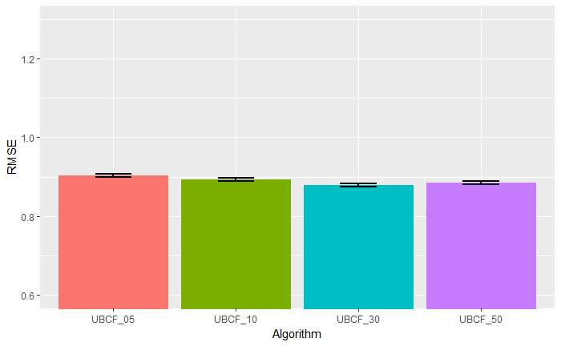

```r
# restructure results output
tmp <- lapply(results, function(x) slot(x, "results"))
res <- tmp %>%
  lapply(function(x) unlist(lapply(x, function(x) unlist(x@cm[ ,"RMSE"])))) %>%
  as.data.frame() %>%
  gather(key = "Algorithm", value = "RMSE")
res %>%
  ggplot(aes(Algorithm, RMSE, fill = Algorithm)) +
  geom_bar(stat = "summary") + geom_errorbar(stat = "summary", width = 0.3, size = 0.8) +
  coord_cartesian(ylim = c(0.6, 1.3)) + guides(fill = FALSE)
```

### Different algorithms

It is also possible to compare the performace of different algorithms. The following algorithms are available:

```r
recommenderRegistry$get_entry_names()
```

[output not shown]

You can get more information about these algorithms:

```r
recommenderRegistry$get_entries(dataType = "realRatingMatrix")
```

[output not shown]

```r
scheme <- evaluationScheme(real_ratings, method = "cross-validation", k = 10, given = -1, goodRating = 5)

algorithms <- list("random" = list(name = "RANDOM", param = NULL),
                   "popular" = list(name = "POPULAR"),

                   "SVD" = list(name = "SVD")
                   )#"UBCF" = list(name = "UBCF"),

results <- evaluate(scheme, algorithms, type = "ratings", progress = FALSE)

# restructure results output
tmp <- lapply(results, function(x) slot(x, "results"))
res <- tmp %>%
  lapply(function(x) unlist(lapply(x, function(x) unlist(x@cm[ ,"RMSE"])))) %>%
  as.data.frame() %>%
  gather(key = "Algorithm", value = "RMSE")

res %>%
  mutate(Algorithm=factor(Algorithm, levels = c("random", "popular", "UBCF", "SVD"))) %>%
  ggplot(aes(Algorithm, RMSE, fill = Algorithm)) + geom_bar(stat = "summary") +
  geom_errorbar(stat = "summary", width = 0.3, size = 0.8) + coord_cartesian(ylim = c(0.6, 1.3)) +
  guides(fill = FALSE)
```

[output not shown]

### Summary Part II

In collaborative filtering the main idea is to use ratings from similar users to create recommendations. The basic algorithm is easy to implement by hand, but there are some packages like Recommenderlab greatly simplyfying your work.